# Expose Vert.x Metrics for Prometheus, visualize in Grafana

This document will show you how to expose Vert.x Metrics for Prometheus and visualize them in Grafana.

## What you will build

You will build a web server that:

- generates greetings upon request on the `EventBus`
- replies to `GET` requests on the `/greeting` path,
- exposes metrics for Prometheus on the `/metrics` path.

Then you will configure Prometheus to scrape the metrics and Grafana to visualize them.

The application fits in just a single `MainVerticle` class

## What you need

- A text editor or IDE
- Java 11 or higher
- Maven or Gradle
- Prometheus (or Docker)
- Grafana (or Docker)

## Create a project

The code of this project contains Maven and Gradle build files that are functionally equivalent.

### Using Maven

Here is the content of the `pom.xml` file you should be using:

Maven `pom.xml`

```
<?xml version="1.0" encoding="UTF-8"?>
<project xmlns="http://maven.apache.org/POM/4.0.0"
         xmlns:xsi="http://www.w3.org/2001/XMLSchema-instance"
         xsi:schemaLocation="http://maven.apache.org/POM/4.0.0 http://maven.apache.org/xsd/maven-4.0.0.xsd">

  <modelVersion>4.0.0</modelVersion>

  <groupId>io.vertx.howtos</groupId>
  <artifactId>metrics-prometheus-grafana-howto</artifactId>
  <version>1.0-SNAPSHOT</version>

  <properties>
    <vertx.version>5.0.0.CR2</vertx.version>
  </properties>

  <dependencyManagement>
    <dependencies>
      <dependency>
        <groupId>io.vertx</groupId>
        <artifactId>vertx-stack-depchain</artifactId>
        <version>${vertx.version}</version>
        <type>pom</type>
        <scope>import</scope>
      </dependency>
    </dependencies>
  </dependencyManagement>

  <dependencies>
    <dependency>
      <groupId>io.vertx</groupId>
      <artifactId>vertx-web</artifactId>
    </dependency>
    <dependency>
      <groupId>io.vertx</groupId>
      <artifactId>vertx-micrometer-metrics</artifactId>
    </dependency>
    <dependency>
      <groupId>io.micrometer</groupId>
      <artifactId>micrometer-registry-prometheus</artifactId>
      <version>1.14.1</version>
    </dependency>
  </dependencies>

  <build>
    <plugins>
      <plugin>
        <groupId>org.apache.maven.plugins</groupId>
        <artifactId>maven-compiler-plugin</artifactId>
        <version>3.13.0</version>
        <configuration>
          <release>11</release>
        </configuration>
      </plugin>
      <plugin>
        <groupId>org.codehaus.mojo</groupId>
        <artifactId>exec-maven-plugin</artifactId>
        <version>3.5.0</version>
        <configuration>
          <mainClass>io.vertx.howtos.metrics.MainVerticle</mainClass>
        </configuration>
      </plugin>
    </plugins>
  </build>

</project>
```

### Using Gradle

Assuming you use Gradle with the Kotlin DSL, here is what your `build.gradle.kts` file should look like:

Gradle `build.gradle.kts`

```
plugins {
  java
  application
}

repositories {
  mavenCentral()
}

java {
  toolchain {
    languageVersion.set(JavaLanguageVersion.of(11))
  }
}

dependencies {
  implementation(platform("io.vertx:vertx-stack-depchain:5.0.0.CR2"))
  implementation("io.vertx:vertx-web")
  implementation("io.vertx:vertx-micrometer-metrics")
  implementation("io.micrometer:micrometer-registry-prometheus:1.14.1")
}

application {
  mainClass = "io.vertx.howtos.metrics.MainVerticle"
}
```

## Implementing the server

### Greeting generator

First, let’s define a few greetings:

Java `src/main/java/io/vertx/howtos/metrics/MainVerticle.java`

```
  private static final String[] GREETINGS = {
    "Hello world!",
    "Bonjour monde!",
    "Hallo Welt!",
    "Hola Mundo!"
  };
```

Then, we will define a consumer for the `greetings` address on the `EventBus`. This consumer picks a random greeting and returns it after an arbitrary amount of time:

Java `src/main/java/io/vertx/howtos/metrics/MainVerticle.java`

```
    Future<Void> registration = vertx.eventBus().consumer("greetings", msg -> {
      // Simulate processing time between 20ms and 100ms
      long delay = ThreadLocalRandom.current().nextLong(80) + 20L;
      vertx.setTimer(delay, l -> {
        // Choose greeting
        String greeting = GREETINGS[ThreadLocalRandom.current().nextInt(GREETINGS.length)];
        msg.reply(greeting);
      });
    }).completion();
```

### HTTP server

We’ll need a Vert.x Web Router to start with:

Java `src/main/java/io/vertx/howtos/metrics/MainVerticle.java`

```
    Router router = Router.router(vertx);
```

Then let’s create a handler for `GET` requests on the `greeting` path:

Java `src/main/java/io/vertx/howtos/metrics/MainVerticle.java`

```
    router.get("/greeting").handler(rc -> {
      vertx.eventBus().<String>request("greetings", null)
        .map(Message::body)
        .onSuccess(greeting -> rc.response().putHeader("content-type", "text/plain").end(greeting))
        .onFailure(throwable -> {
          throwable.printStackTrace();
          rc.fail(500);
        });
    });
```

The Vert.x Micrometer Metrics module provides a Vert.x Web handler that comes in handy when you need to expose data in the Prometheus text format:

Java `src/main/java/io/vertx/howtos/metrics/MainVerticle.java`

```
    router.route("/metrics").handler(PrometheusScrapingHandler.create());
```

With the Vert.x Web Router configured, we can start the HTTP server:

Java `src/main/java/io/vertx/howtos/metrics/MainVerticle.java`

```
    Future<HttpServer> httpServer = vertx.createHttpServer()
      .requestHandler(router)
      .listen(8080);
```

Lastly, the `MainVerticle` needs a `main` method:

Java `src/main/java/io/vertx/howtos/metrics/MainVerticle.java`

```
  public static void main(String[] args) {
    /*
     We can configure the metrics registry to enable histogram buckets
     for percentile approximations.
     */
    PrometheusMeterRegistry registry = new PrometheusMeterRegistry(PrometheusConfig.DEFAULT);
    registry.config().meterFilter(
      new MeterFilter() {
        @Override
        public DistributionStatisticConfig configure(Meter.Id id, DistributionStatisticConfig config) {
          return DistributionStatisticConfig.builder()
            .percentilesHistogram(true)
            .build()
            .merge(config);
        }
      });

    Vertx vertx = Vertx.builder()
      .with(new VertxOptions().setMetricsOptions(new MicrometerMetricsOptions()
        .setEnabled(true)
        .setPrometheusOptions(new VertxPrometheusOptions()
          .setEnabled(true))
      ))
      .withMetrics(new MicrometerMetricsFactory(registry))
      .build();

    vertx.deployVerticle(new MainVerticle()).await();
    System.out.println("Verticle started");
  }
```

|  | The Vert.x instance must be created with metrics options enabled. |
| --- | --- |

## Running the application

You can run the application:

- straight from your IDE or,
- with Maven: `mvn compile exec:java`, or
- with Gradle: `./gradlew run` (Linux, macOS) or `gradlew run` (Windows).

The following examples use the [HTTPie](https://httpie.org/) command line HTTP client. Please refer to the installation documentation if you don’t have it installed on your system yet.

### Testing the greeting server

To get a greeting from the server, open your terminal and execute this:

```
http :8080/greeting
```

You should see something like:

```
HTTP/1.1 200 OK
content-length: 11
content-type: text/plain

Hola Mundo!
```

### Testing the metrics endpoint

To get the metrics:

```
http :8080/metrics
```

You should see something like:

[output not shown]

[output not shown]

[output not shown]

[output not shown]

[output not shown]

[output not shown]

[output not shown]

[output not shown]

## Scraping with Prometheus

If you’re not familiar with Prometheus, check out the [getting started guide](https://prometheus.io/docs/prometheus/latest/getting_started/).

You need to configure the Prometheus server to scrape `localhost:8080`.

```
  - job_name: 'vertx-8080'
    static_configs:
      - targets: ['localhost:8080']
```

To run a pre-configured Prometheus server on your machine with Docker, clone the repository of this tutorial, open your terminal and execute this:

```
docker run --network host -v ${PWD}/prometheus:/etc/prometheus -it prom/prometheus
```

## Visualizing with Grafana

If you’re not familiar with Grafana, check out the [getting started guide](https://grafana.com/docs/grafana/latest/guides/getting_started/).

To run a Grafana server on your machine with Docker, clone the repository of this tutorial, open your terminal and execute this:

```
docker run --network host -it grafana/grafana
```

As a starting point, you can import the dashboard from `grafana/dashboard.json`.

You should see something like:

Dashboard

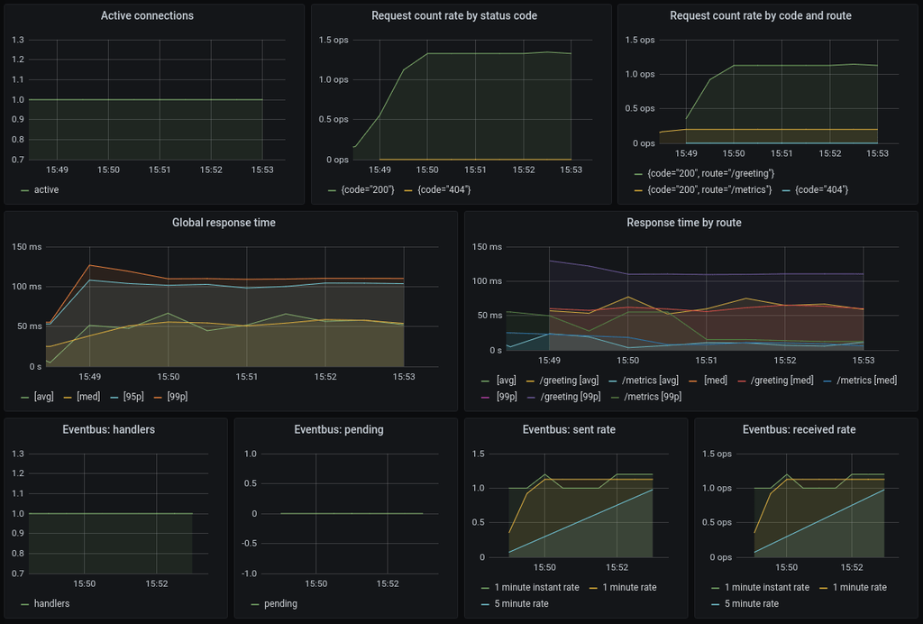

## Summary

This document covered:

1. setting up Vert.x to expose metrics for Prometheus,
2. visualizing metric data in Grafana.

## See also

- Vert.x Micrometer Metrics documentation